# Analiza UFC borbi

## Pitanje 1:

### Možemo li očekivati završetak borbe nokautom ovisno o razlici u dužini ruku između boraca?

#### Odabir metode

Ovo pitanje možemo preformulirati kao: *Postoji li zavisnost između razlike u dužini ruku boraca i završetka borbe nokautom?*  
Pa tako možemo postaviti i pitanje: *Postoji li nezavisnost između razlike u dužini ruku boraca i završetka borbe nokautom?*  
Prema ovim pitanjima moglo bi se zaključiti da bi trebalo provesti test nezavisnosti, no ključna informacija je da obje varijable nisu kategorijeske - razlika duljine ruku između boraca je kvantitativna varijabla, dok je ishod borbe kategorijska varijabla. Iz tog razloga test nezavisnosti nije valjana opcija za dobivanje odgovora na ovo pitanje.

Pošto test nezavisnosti nije dobra opcija, druga metoda kojom bi se moglo doći do odgovora na ovo pitanje je **analiza varijance**. Imajući samo jednu nezavisnu varijablu (razlika duljine ruku između boraca) riječ je o jednofaktorskoj analizi varijance.

```r
head(total_fight$B_Weight)
```

```
## [1] "135 lbs." "205 lbs." "241 lbs." "115 lbs." "135 lbs." "145 lbs."
```

```r
total_fight$R_Reach = strtoi(substr(total_fight$R_Reach, 1, 2))
total_fight$B_Reach = strtoi(substr(total_fight$B_Reach, 1, 2))
head(total_fight$R_Reach)
```

```
## [1] 70 74 75 63 68 75
```

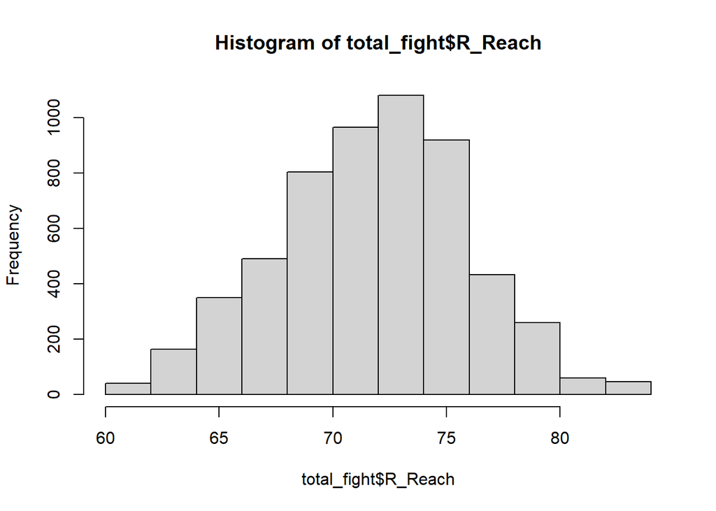

```r
hist(total_fight$R_Reach)
```

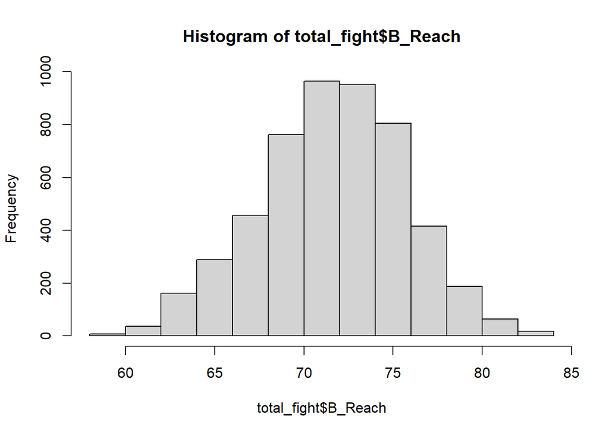

```r
hist(total_fight$B_Reach)
```

## Uvod

#### Filtriranje podataka

Pošto smo već prije uočili da u ovim varijablama postoje objekti koji nemaju vrijednosti, prije nego li počnemo raditi s njima, podatci će prvo biti profiltrirani kako bi se nezadovoljavajući objekti uklonili:

```r
  arm_lengths <- select(total_fight, c("B_Reach", "R_Reach"))
  arm_lengths <- arm_lengths[rowSums(is.na(arm_lengths)) == 0, ]
  arm_lengths[0:20, ]
```

```
##    B_Reach R_Reach
## 1       67      70
## 2       76      74
## 3       75      75
## 4       61      63
## 5       72      68
## 6       72      75
## 7       76      71
## 8       81      77
## 9       70      75
## 11      66      68
## 12      79      77
## 13      72      74
## 14      71      69
## 15      74      75
## 16      69      64
## 17      69      70
## 18      66      71
## 19      70      72
## 20      67      67
## 21      70      75
```

```r
  # provjera za razliku duljine ruku
  for (name in names(arm_lengths)) {
    if (sum(is.na(arm_lengths[, name])) > 0) {
      cat('Broj nedostajućih vrijednosti za varijablu ', name, ': ', sum(is.na(arm_lengths[, name])), '\n')
    }
  }

  win_methods <- select(total_fight, c("B_Reach", "R_Reach", "win_by"))
  win_methods <- win_methods[rowSums(is.na(win_methods)) == 0, ]
  win_methods <- select(win_methods, c("win_by"))
  win_methods <- win_methods$win_by
  win_methods[0:21]
```

```
##  [1] "KO/TKO"               "Decision - Unanimous" "KO/TKO"
##  [4] "Decision - Unanimous" "Decision - Unanimous" "KO/TKO"
##  [7] "KO/TKO"               "Decision - Unanimous" "KO/TKO"
## [10] "Decision - Split"     "KO/TKO"               "Could Not Continue"
## [13] "KO/TKO"               "Could Not Continue"   "Decision - Unanimous"
## [16] "KO/TKO"               "KO/TKO"               "Decision - Unanimous"
## [19] "Decision - Split"     "KO/TKO"               "Submission"
```

```r
  # provjera za razlog pobjede
  for (name in names(win_methods)) {
    if (sum(is.na(win_methods[, name])) > 0) {
      cat('Broj nedostajućih vrijednosti za varijablu ', name, ': ', sum(is.na(win_methods[, name])), '\n')
    }
  }
```

Pošto nema ispisa možemo zaključiti da su svi nezadovoljavajući objekti uklonjeni.

Sada možemo nastaviti raditi sa podatcima.

### Pretpostavke

Kod provođenja testa moramo provijeriti zadovoljavaju li naši podatci preduvjete potrebne za provođenje izabrane metode. Pošto smo za odgovor na ovo pitanje odlučili provesti jednofaktorsku analizu varijance, preduvjeti su sljedeći:

#### Test se provodi na podatcima koji su slučajno izabrani iz populacije

Koristi se pretpostavka da su podatci na kojima se provode testovi slučajno izabrani iz populacije

#### Zavisna kvantitativna varijabla mora pratiti normalnu distribuciju

```r
 arm_length_differences <- (arm_lengths$B_Reach - arm_lengths$R_Reach)
 arm_length_differences[0:76]
```

```
##  [1] -3  2  0 -2  4 -3  5  4 -5 -2  2 -2  2 -1  5 -1 -5 -2  0 -5  3 -2  0  5  4
## [26]  2  2  2  3  0  3  2  2  7 -6  1  1  3 -2  0 -2  3  0  2 -2  2 -4  0 -2 -1
## [51]  2  1 -1  0  1  2  2  0  1  3 -3 -5 -3  1 -4  2  7 -8  1  3 -8 -3  0 -2 -2
## [76] -5
```

Možemo uočiti da su razlike duljina ruku cijeli brojevi, što je pomalo neočekivano, no razlog tomu je što su početne vrijednosti bile u mjernoj jedinici *inch*, te će tako ostati do završnog rezultata kako bi se očuvala točnost podataka. Pošto je sada sve u redu, možemo početi sa ispitivanjem normalnosti ove varijable. Jedan od najlakših i najefikasnijih načina provjere normalnosti je histogram.

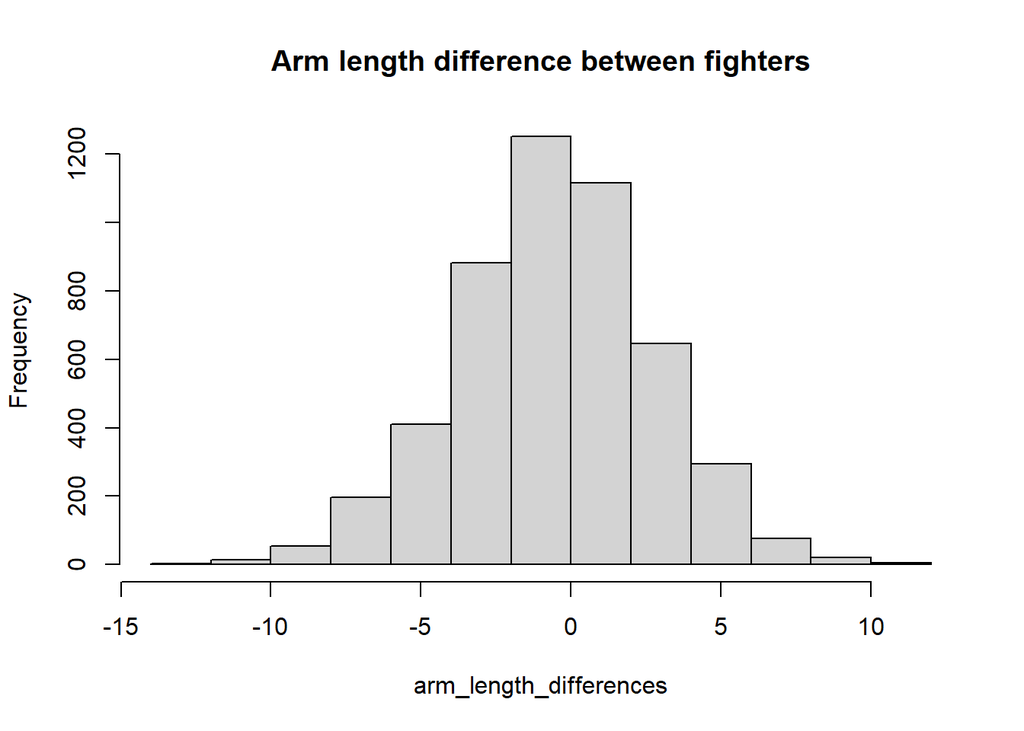

```r
hist(arm_length_differences, main='Arm length difference between fighters')
```

Iz histograma možemo zaključiti da su podatci relativno lijepo raspoređeni po normalnoj distribuciji. Kao još jedan dijagnostički alat, možemo napraviti i Q-Q plot.

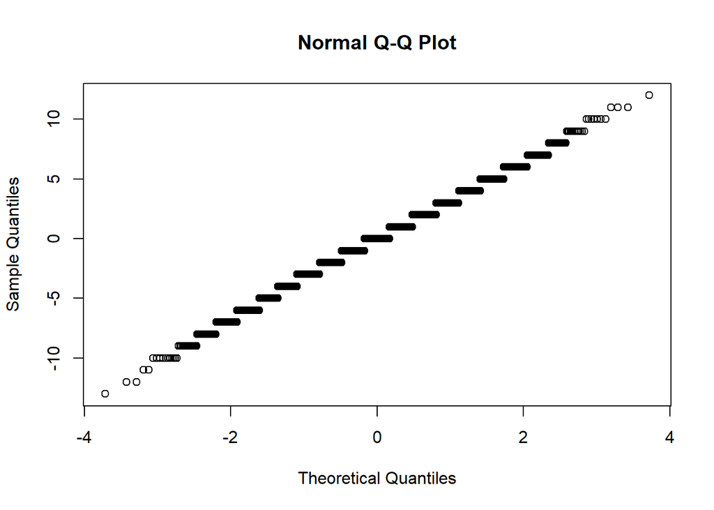

```r
qqnorm(arm_length_differences)
```

Kao što možemo vidjeti, Q-Q plot također daje poprilično dobre indikacije da se radi o normalnoj distribuciji. Kao konačnu potvrdu naše pretpostavke, koristiti ćemo Lillieforsov test:

```r
require(nortest)
lillie.test(arm_length_differences)
```

```
##
##  Lilliefors (Kolmogorov-Smirnov) normality test
##
## data:  arm_length_differences
## D = 0.073975, p-value < 2.2e-16
```

```r
lillie.test(sample(arm_length_differences, size = 100))
```

```
##
##  Lilliefors (Kolmogorov-Smirnov) normality test
##
## data:  sample(arm_length_differences, size = 100)
## D = 0.089651, p-value = 0.04606
```

Prema rezultatima Lillieforsovog testa možemo zaključiti da podatci nisu normalno distribuirani, obrnuto od naše pretpostavke, no moramo uzeti u obzir da niti Lillieforsov test ne daje sigurnost u distribuciju podataka, pošto što je skup podataka veći, to je test osjetljiviji na normalnost istih podataka. Stoga ćemo se oslanjati na robusnost ANOVA-e na normalnost pri grupama iste veličine.

#### Homogenost varijance u svim grupama (homoskedastičnost)

Homogenost varijance kroz grupe inicijalno možemo provjeriti boxplotom:

```r
question_1_data <- data.frame(arm_length_differences, win_methods)
# stvaranje dviju grupa u nezavisnoj kategorijskoj varijabli
question_1_data$win_methods <- replace(question_1_data$win_methods, question_1_data$win_methods != "KO/TKO", "Other")
# length(question_1_data$win_methods[question_1_data$win_methods == "KO/TKO"])
# length(question_1_data$win_methods[question_1_data$win_methods != "KO/TKO"])
# nasumično uzimanje uzorka kako bi se stvorile grupe iste veličine
# za reproducibilnost
set.seed(8919)
other <- sample_n(tbl = question_1_data[question_1_data$win_methods != "KO/TKO", ], size = 1533)
KO <- question_1_data[question_1_data$win_methods == "KO/TKO", ]

# grupe iste veličine
question_1_data <- rbind(KO, other)

question_1_data[0:10, ]
```

```
##    arm_length_differences win_methods
## 1                      -3      KO/TKO
## 3                       0      KO/TKO
## 6                      -3      KO/TKO
## 7                       5      KO/TKO
## 9                      -5      KO/TKO
## 11                      2      KO/TKO
## 13                      2      KO/TKO
## 16                     -1      KO/TKO
## 17                     -5      KO/TKO
## 20                     -5      KO/TKO
```

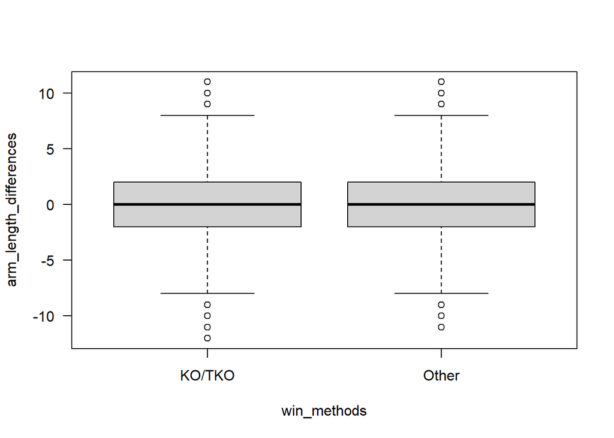

```r
boxplot(arm_length_differences ~ win_methods, data = question_1_data, las = 1)
```

Iz boxplota možemo zaključiti da varijanca gotovo ne odstupa ovisno o razlogu pobjede, stoga smatramo da je i ovaj preduvjet za provedbu analize varijance zadovoljen. Također, možemo vidjeti kako se srednje vrijednosti ovisno o vrijednosti kategorijske varijable skoro pa ne razlikuju, što nam govori da vjerojatno nećemo imati dovoljno dokaza za odbacivanje hipoteze H0 u korist hipoteze H1.

Kao potvrdu o hipotezi za jednakost varijance napraviti ćemo Bartlettov test:

```r
# H0: varijance svih grupa su iste
# H1: varijance barem dviju grupa su različite

bartlett.test(question_1_data$arm_length_differences ~ question_1_data$win_methods)
```

```
##
##  Bartlett test of homogeneity of variances
##
## data:  question_1_data$arm_length_differences by question_1_data$win_methods
## Bartlett's K-squared = 1.2915, df = 1, p-value = 0.2558
```

```r
var((question_1_data$arm_length_differences[question_1_data$win_methods == "KO/TKO"]))
```

```
## [1] 10.96634
```

```r
var((question_1_data$arm_length_differences[question_1_data$win_methods != "KO/TKO"]))
```

```
## [1] 10.34751
```

U vidu dobivenih rezultata iz Bartlettovog testa ne možemo odbaciti hipotezu H0 u korist hipoteze H1 na razini signifikantnosti 0.05, drugim riječima - imamo indikacije da su varijance grupa jednake, te s time da je preduvjet homoskedastičnosti zadovoljen.

Pošto su svi preduvjeti zadovoljeni, možemo početi sa provođenjem testiranje.

## Testiranje

Provodimo jednofaktorski ANOVA test:

### Hipoteze

#### Hipoteza H0: srednje vrijednosti obiju grupa su iste

#### Hipoteza H1: srednje vrijednost grupa su različite

```r
# contrast_matrix <- matrix(nrow = 2, ncol = 9,
#                           c(0,0,0,0,0,0,0,0,0,
#                           0,0,0,0,0,0,0,0,0,
#                           0,0,0,0,0,0,0,0,0,
#                           0,0,0,0,0,0,0,0,0,
#                           0,0,0,0,0,0,0,0,0,
#                           1,1,1,1,1,-8,1,1,1,
#                           0,0,0,0,0,0,0,0,0,
#                           0,0,0,0,0,0,0,0,0,
#                           0,0,0,0,0,0,0,0,0))
# colnames(contrast_matrix) <- c("Could Not Continue", "Decision - Majority", "Decision - Split", "Decision - Unanimous", "DQ", "KO/TKO", "Overturned", "Submission", "TKO - Doctor's Stoppage")
contrast_matrix <- matrix(nrow = 2, ncol = 1, c(0, 1))
colnames(contrast_matrix) <- c("KO/TKO")
question_1_data$win_methods <- factor(question_1_data$win_methods)
contrasts(question_1_data$win_methods) <- contrast_matrix
contrasts(question_1_data$win_methods)
```

```
##        KO/TKO
## KO/TKO      0
## Other       1
```

```r
result <- aov(question_1_data$arm_length_differences ~ question_1_data$win_methods)
summary(result)
```

```
##                               Df Sum Sq Mean Sq F value Pr(>F)
## question_1_data$win_methods    1      0   0.471   0.044  0.834
## Residuals                   3064  32653  10.657
```

```r
model <- lm(question_1_data$arm_length_differences ~ question_1_data$win_methods)
summary(model)
```

```
##
## Call:
## lm(formula = question_1_data$arm_length_differences ~ question_1_data$win_methods)
##
## Residuals:
##      Min       1Q   Median       3Q      Max
## -11.8565  -1.8813   0.1187   2.1187  11.1435
##
## Coefficients:
##                                   Estimate Std. Error t value Pr(>|t|)
## (Intercept)                       -0.14351    0.08338  -1.721   0.0853 .
## question_1_data$win_methodsKO/TKO  0.02479    0.11791   0.210   0.8335
## ---
## Signif. codes:  0 '***' 0.001 '**' 0.01 '*' 0.05 '.' 0.1 ' ' 1
##
## Residual standard error: 3.264 on 3064 degrees of freedom
## Multiple R-squared:  1.442e-05,  Adjusted R-squared:  -0.0003119
## F-statistic: 0.04419 on 1 and 3064 DF,  p-value: 0.8335
```

```r
anova(model)
```

```
## Analysis of Variance Table
##
## Response: question_1_data$arm_length_differences
##                               Df Sum Sq Mean Sq F value Pr(>F)
## question_1_data$win_methods    1      0   0.471  0.0442 0.8335
## Residuals                   3064  32653  10.657
```

### Zaključak

U vidu dobivenih dokaza, ne možemo odbaciti hipotezu H0 u korist hipoteze H1 na razini signifikantnosti 0.05.

Odgovor na početno pitanje bi glasio:  
**“Ne, ne možemo očekivati završetak borbe nokautom ovisno o razlici duljine ruku boraca”**

#### Pitanje 2:

##### Razlikuje li se trajanje mečeva (u sekundama) izmedu pojedinih kategorija?

```r
#cleaning data

#adding total time fought in seconds
library(stringr)
last_round_vector = stringr::str_split_fixed(fights$last_round_time, pattern = ":", 2)

fights <- cbind(fights, total_time_in_seconds = (fights$last_round - 1)*5*60)
for(i in 1:length(fights$total_time_in_seconds)) {
  fights$total_time_in_seconds[i] = fights$total_time_in_seconds[i] + strtoi(last_round_vector[i], base = 10L) * 60 + strtoi((last_round_vector[i,])[2], base = 10L)
}
#hist(fights$total_time_in_seconds)

# dividing fights by categories

beginFights <- fights %>% filter(grepl("Women's|Strawweight|Flyweight|Bantamweight|Featherweight|Lightweight|Welterweight|Middleweight|Light Heavyweight|Heavyweight", Fight_type, ignore.case = TRUE))
beginFights <- cbind(beginFights, categories = gsub("UFC | Title| Bout| Tournament|[0-9] |Interim |Super |Ultimate Fighter |[0-9]|Australia |Brazil |Latin America |Ultimate Japan|vs. UK |UF Nations Canada vs. |T", "", beginFights$Fight_type))
beginFights$categories <- trimws(beginFights$categories)

#all categories
validFights = beginFights
validFights$categories = factor(validFights$categories, levels = c("Women's Strawweight", "Women's Flyweight", "Women's Bantamweight", "Women's Featherweight", "Flyweight", "Bantamweight", "Featherweight", "Lightweight", "Welterweight", "Middleweight", "Light Heavyweight", "Heavyweight"), labels = c('womensStrawweight', 'womensFlyweight', 'womensBantamweight', 'womensFeatherweight', 'Flyweight', 'Bantamweight', 'Featherweight', 'Lightweight', 'Welterweight', 'Middleweight', 'LightHeavyweight', 'Heavyweight'))
```

```r
print(noquote("Raspodjela podataka po kategorijama"))
```

```
## [1] Raspodjela podataka po kategorijama
```

```r
summary(validFights$categories)
```

```
##   womensStrawweight     womensFlyweight  womensBantamweight womensFeatherweight
##                 175                 103                 141                  16
##           Flyweight        Bantamweight       Featherweight         Lightweight
##                 208                 431                 478                1014
##        Welterweight        Middleweight    LightHeavyweight         Heavyweight
##                 984                 751                 526                 541
```

```r
# lengths(dataTimeFoughtInSeconds, use.names = TRUE)
print(noquote("Sažetak trajanja borbi u sekundama"))
```

```
## [1] Sažetak trajanja borbi u sekundama
```

```r
summary(validFights$total_time_in_seconds)
```

```
##    Min. 1st Qu.  Median    Mean 3rd Qu.    Max.
##     5.0   273.0   782.0   626.4   900.0  1500.0
```

Možemo prikazati podatke u boxplotu i usporediti ih:

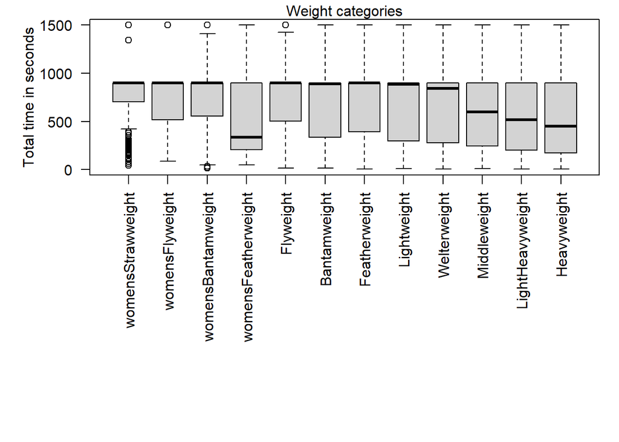

```r
par(mar=c(15, 5, 1, 1) + 0.1)
boxplot(validFights$total_time_in_seconds ~ validFights$categories, ylab = "Total time in seconds", xlab="", las = 2)
mtext("Weight categories", side=3)
```

Testiranje normalnosti ćemo provesti nad svim podacima, i podacima podijeljenim u grupe prema kategoriji.

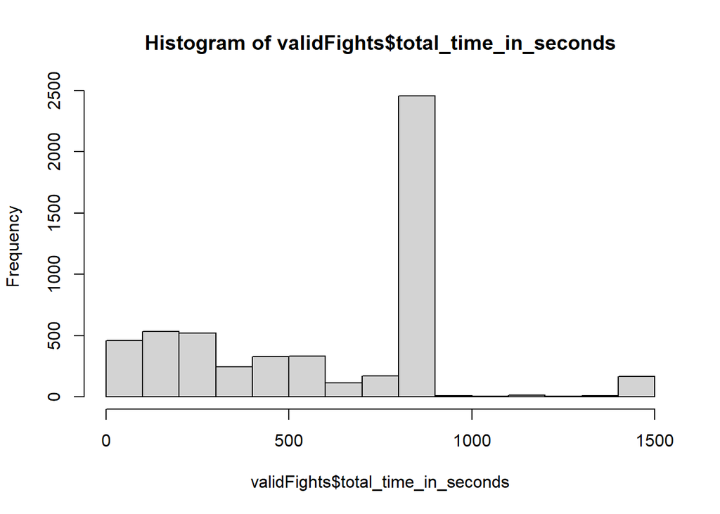

```r
hist(validFights$total_time_in_seconds)
```

```r
require(nortest)
lillie.test(validFights$total_time_in_seconds)
```

```
##
##  Lilliefors (Kolmogorov-Smirnov) normality test
##
## data:  validFights$total_time_in_seconds
## D = 0.24339, p-value < 2.2e-16
```

Iz histograma svih podataka i Lillieforsovog testa nad tim podacima možemo zaključiti da podaci ne prate normalnu razdiobu, ali da budemo sigurni možemo testirati i svaki zasebnu grupu podataka. Radi sažetosti, ispitivali smo samo ako je p-vrijednost bilo koje grupe veća od $\alpha = 0.05$.

```r
categoryLevels = levels(validFights$categories)
normalnostGrupe = FALSE
for(i in 1:length(categoryLevels)) {
  pVrijednost = lillie.test(validFights$total_time_in_seconds[validFights$categories==categoryLevels[i]])$p.value
  if (pVrijednost >= 0.05)
    normalnostGrupe = TRUE
}

if(normalnostGrupe) {
  print(noquote("Barem jedna grupa prati normalnu razdiobu."))
} else {
  print(noquote("Nijedna grupa ne prati normalnu razdiobu."))
}
```

```
## [1] Nijedna grupa ne prati normalnu razdiobu.
```

Homogenost varijanci različitih populacija ćemo testirati Levenovim testom, jer je manje osjetljiv na odstupanje od normalnosti nego Bartlettov test.

```r
library(car)
leveneTest(total_time_in_seconds ~ categories, validFights)
```

```
## Levene's Test for Homogeneity of Variance (center = median)
##         Df F value    Pr(>F)
## group   11  9.7432 < 2.2e-16 ***
##       5356
## ---
## Signif. codes:  0 '***' 0.001 '**' 0.01 '*' 0.05 '.' 0.1 ' ' 1
```

```r
adjustedValidFights <- beginFights %>% filter(!grepl("Women's Featherweight", Fight_type, ignore.case = TRUE))

adjustedValidFights$categories = factor(adjustedValidFights$categories, levels = c("Women's Strawweight", "Women's Flyweight", "Women's Bantamweight", "Flyweight", "Bantamweight", "Featherweight", "Lightweight", "Welterweight", "Middleweight", "Light Heavyweight", "Heavyweight"), labels = c('womensStrawweight', 'womensFlyweight', 'womensBantamweight', 'Flyweight', 'Bantamweight', 'Featherweight', 'Lightweight', 'Welterweight', 'Middleweight', 'LightHeavyweight', 'Heavyweight'))

adjustedValidFights <- adjustedValidFights %>% group_by(categories) %>% slice_sample(n=100)

a = aov(adjustedValidFights$total_time_in_seconds ~ adjustedValidFights$categories)
summary(a)
```

```
##                                  Df    Sum Sq Mean Sq F value   Pr(>F)
## adjustedValidFights$categories   10   7474162  747416   6.077 4.81e-09 ***
## Residuals                      1089 133942889  122996
## ---
## Signif. codes:  0 '***' 0.001 '**' 0.01 '*' 0.05 '.' 0.1 ' ' 1
```

Možemo odbaciti H0 u korist H1, time zaključujemo da postoje barem dvije grupe kojima se trajanje mečeva razlikuje.

#### Pitanje 3:

##### Traju li (u rundama) borbe za titulu duže od ostalih borbi u natjecanju?

Radimo tablicu u kojoj je trajanje samo borbe za naslov prvaka kategorije. Takve borbe mogu trajati najviše 5 rundi.

```r
bouts = select(fights, c("Fight_type", "last_round"))
#names(bouts)

titleFights <- fights %>% filter(grepl("title", Fight_type, ignore.case = TRUE))
#titleFights

head(
  select(titleFights, R_fighter, B_fighter, Fight_type, last_round, Winner)
)
```

```
##              R_fighter         B_fighter                           Fight_type
## 1             Petr Yan Aljamain Sterling          UFC Bantamweight Title Bout
## 2       Jan Blachowicz   Israel Adesanya     UFC Light Heavyweight Title Bout
## 3         Amanda Nunes    Megan Anderson UFC Women's Featherweight Title Bout
## 4         Kamaru Usman     Gilbert Burns          UFC Welterweight Title Bout
## 5  Deiveson Figueiredo    Brandon Moreno             UFC Flyweight Title Bout
## 6 Valentina Shevchenko     Jennifer Maia     UFC Women's Flyweight Title Bout
##   last_round               Winner
## 1          4    Aljamain Sterling
## 2          5       Jan Blachowicz
## 3          1         Amanda Nunes
## 4          3         Kamaru Usman
## 5          5
## 6          5 Valentina Shevchenko
```

```r
titleFightDuration <- titleFights$last_round   #lista u koju spremamo trajanja svih title fightova
```

U ispisu vidimo da neki title fightovi nemaju pobjednika. Ako je borba završila u 5. rundi i nema pobjednika riječ je o Drawu, odnosno odluka sudaca je da su borci izjednačeni. Ako je borba završila prije 5. runde i nema pobjednika, što je iznimno rijetko, mora biti riječ o No Contestu, odnosno borba je prekinuta iz nekog razloga i nemoguće je odrediti pobjednika (npr. jednom je protivniku nanesen nenamjeran faul zbog kojeg ne može nastaviti borbu)

Računamo varijancu trajanja borbi koje su za naslov prvaka kategorije.

```r
var(titleFightDuration)
```

```
## [1] 2.651129
```

Na isti način filtriramo samo borbe koje nisu za titulu šampiona. Te borbe uvijek traju najviše 3 runde, osim ako je riječ o borbi koja je main event. Tada borba može trajati do 5 rundi. Takvih je slučajeva jako malo u usporedbi s non-title borbama koje traju do 3 runde

```r
nonTitleFights <- fights %>% filter(!grepl("title", Fight_type, ignore.case = TRUE))
#nonTitleFights

head(
  select(nonTitleFights, R_fighter, B_fighter, Fight_type, last_round, Winner)
)
```

```
##         R_fighter         B_fighter                Fight_type last_round
## 1    Adrian Yanez     Gustavo Lopez         Bantamweight Bout          3
## 2    Trevin Giles     Roman Dolidze         Middleweight Bout          3
## 3     Tai Tuivasa   Harry Hunsucker          Heavyweight Bout          1
## 4   Cheyanne Buys Montserrat Conejo  Women's Strawweight Bout          3
## 5   Marion Reneau     Macy Chiasson Women's Bantamweight Bout          3
## 6 Leonardo Santos      Grant Dawson          Lightweight Bout          3
##              Winner
## 1      Adrian Yanez
## 2      Trevin Giles
## 3       Tai Tuivasa
## 4 Montserrat Conejo
## 5     Macy Chiasson
## 6      Grant Dawson
```

```r
nonTitleFightDuration <- nonTitleFights$last_round
```

Računamo varijancu trajanja borbi koje nisu za naslov prvaka kategorije.

```r
var(nonTitleFightDuration)
```

```
## [1] 0.8879308
```

Vidimo da borbe koje nisu za titulu šampiona imaju puno manju varijancu, što je očekivano jer većina takvih borbi može trajati maksimalno 3 runde.

Za početak radimo Q-Q plot trajanja borbi za naslov šampiona kako bismo ustvrdili radi li se o normalnoj distribuciji

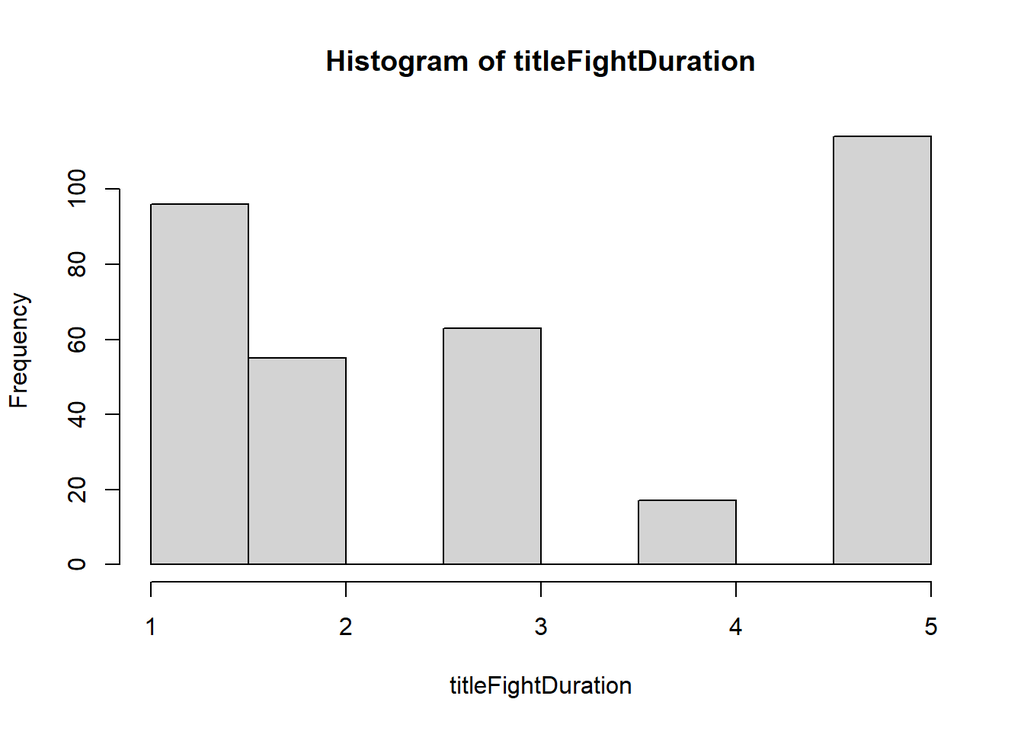

```r
hTitleFights <- hist(titleFightDuration)
```

```r
hTitleFights
```

```
## $breaks
## [1] 1.0 1.5 2.0 2.5 3.0 3.5 4.0 4.5 5.0
##
## $counts
## [1]  96  55   0  63   0  17   0 114
##
## $density
## [1] 0.55652174 0.31884058 0.00000000 0.36521739 0.00000000 0.09855072 0.00000000
## [8] 0.66086957
##
## $mids
## [1] 1.25 1.75 2.25 2.75 3.25 3.75 4.25 4.75
##
## $xname
## [1] "titleFightDuration"
##
## $equidist
## [1] TRUE
##
## attr(,"class")
## [1] "histogram"
```

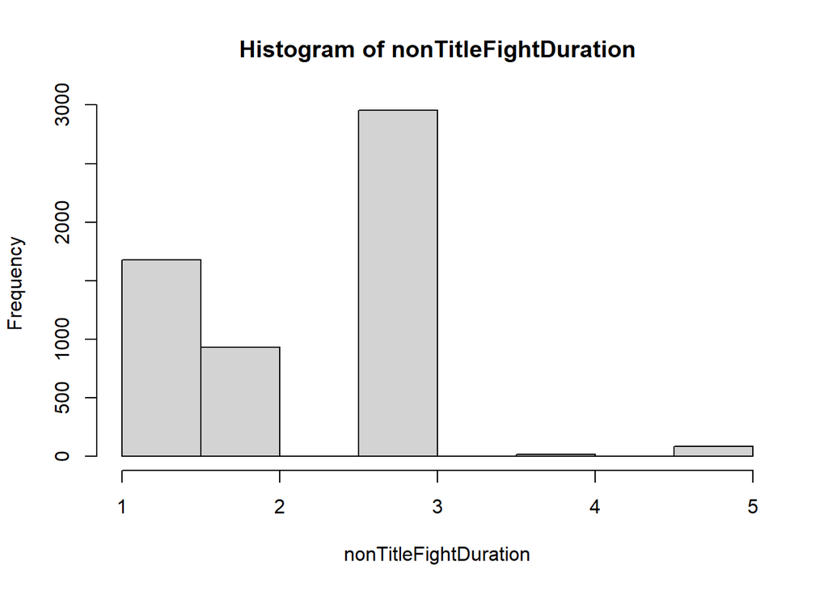

```r
hNonTitleFights <- hist(nonTitleFightDuration)
```

```r
hNonTitleFights
```

```
## $breaks
## [1] 1.0 1.5 2.0 2.5 3.0 3.5 4.0 4.5 5.0
##
## $counts
## [1] 1679  934    0 2953    0   16    0   85
##
## $density
## [1] 0.592553379 0.329627669 0.000000000 1.042173990 0.000000000 0.005646727
## [7] 0.000000000 0.029998235
##
## $mids
## [1] 1.25 1.75 2.25 2.75 3.25 3.75 4.25 4.75
##
## $xname
## [1] "nonTitleFightDuration"
##
## $equidist
## [1] TRUE
##
## attr(,"class")
## [1] "histogram"
```

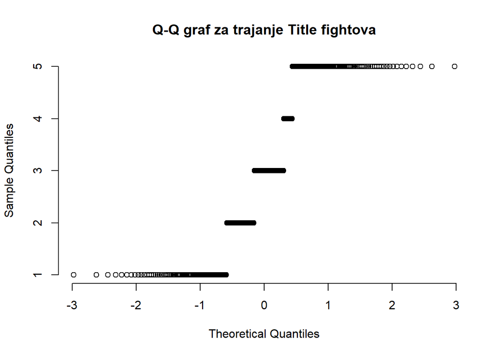

```r
qqnorm(titleFightDuration, pch=1, frame=FALSE, main="Q-Q graf za trajanje Title fightova")
```

Vidimo da graf nimalo ne upućuje da se su trajanja borbi za titulu normalno raspodjeljena. Napravimo isti test za borbe koje nisu za naslov šampiona.

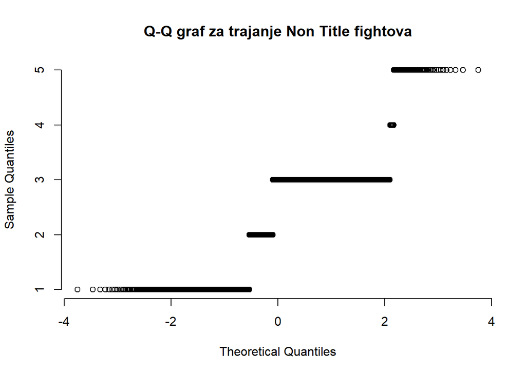

```r
qqnorm(nonTitleFightDuration, pch=1, frame=FALSE, main="Q-Q graf za trajanje Non Title fightova")
```

```r
# TO DO:
#dodaj bar plot sa razdiobom trajanja title fightsa  ->  koristi ggplot paket!!!
length(titleFightDuration[titleFightDuration == 5])
```

```
## [1] 114
```

```r
#dodaj bar plot sa razdiobom trajanja non title fightsa
```

```r
hTitleFights$counts[hTitleFights$counts != 0]
```

```
## [1]  96  55  63  17 114
```

```r
postotciZavrsetakaURundiTitle <- hTitleFights$counts[hTitleFights$counts != 0] / sum(hTitleFights$counts[hTitleFights$counts != 0])
postotciZavrsetakaURundiTitle
```

```
## [1] 0.27826087 0.15942029 0.18260870 0.04927536 0.33043478
```

```r
hNonTitleFights$counts[hNonTitleFights$counts != 0]
```

```
## [1] 1679  934 2953   16   85
```

```r
postotciZavrsetakaURundiNormal <- hNonTitleFights$counts[hNonTitleFights$counts != 0] / sum(hNonTitleFights$counts[hNonTitleFights$counts != 0])
postotciZavrsetakaURundiNormal
```

```
## [1] 0.296276690 0.164813834 0.521086995 0.002823363 0.014999118
```

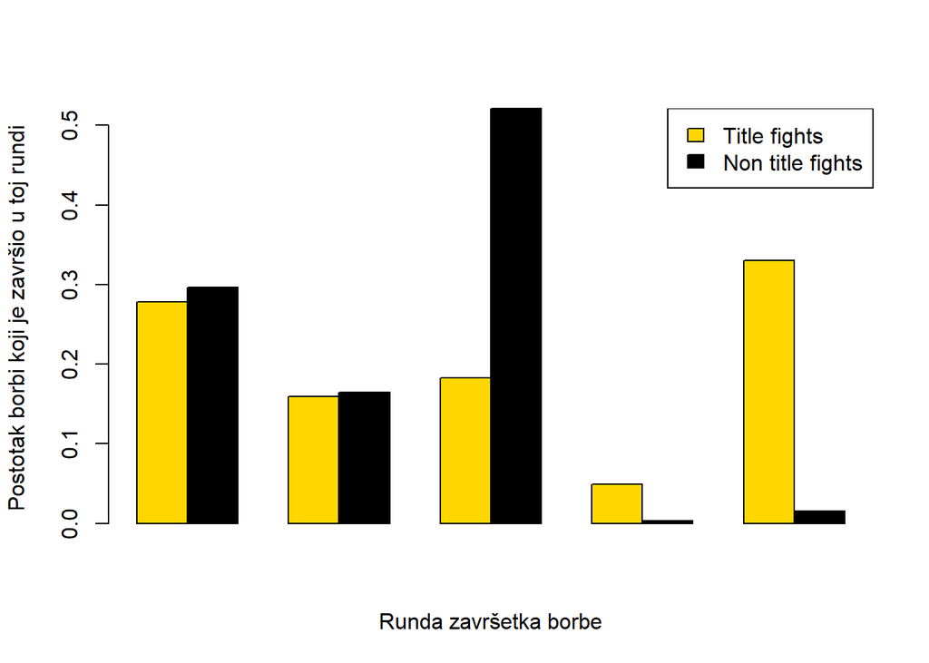

```r
df <- t(cbind(postotciZavrsetakaURundiTitle, postotciZavrsetakaURundiNormal))



barplot(df, beside=TRUE, xlab="Runda završetka borbe", ylab="Postotak borbi koji je završio u toj rundi", col=c("gold", "black"))
legend("topright",c("Title fights", "Non title fights"), fill=c("gold", "black"))
```

I opet smo se uvjerili da nije ni blizu riječ o normalnoj distribuciji.

Ali pogledajmo svejedno kakav bi rezultat dobili da koristimo T-test.

T-test H0: titleFightDuration = nonTitleFightDuration H1: titleFightDuration > nonTitleFightDuration

```r
t.test(titleFightDuration, nonTitleFightDuration, alt="greater", var.equal=FALSE)
```

```
##
##  Welch Two Sample t-test
##
## data:  titleFightDuration and nonTitleFightDuration
## t = 8.1169, df = 358.16, p-value = 3.882e-15
## alternative hypothesis: true difference in means is greater than 0
## 95 percent confidence interval:
##  0.5727189       Inf
## sample estimates:
## mean of x mean of y
##  2.994203  2.275454
```

Iz T-testa bi odbacili početnu hipotezu H0 da borbe za titulu šampiona u prosjeku traju jednako kao obične borbe koje nisu za titulu šampiona jer je p-vrijednost jako jako mala.

```r
# napravi Wilcoxon Rank-Sum Test
```

# Pitati

## slučaju da nemamo pristup cijeloj populaciji, korisitit ćemo T-test za dvije populacije sa poznatim varijancama

U oba slučaja moramo provijeriti normalnost distribucije varijabli sa histogramima i Q-Q plotovima. Vjerojatno će biti potrebno odstraniti  
neke podatke pošto postoje ekstremi. Run a independency test to prove independence.

## Pitanje 4:

#### Mogu li dostupne značajke predvidjeti pobjednika?

U ovom zadatku koristimo logističku regresiju jer nas zanima ako se određeni borac sam po svojim karakteristikama može svrstati u pobjetnika ili gubitnika. Kako je rezultat (zavisna varijabla) binaran, definirat ćemo ga kao Winner = 0/1;

Nakon stvaranja modela sa svim atributima vezanih uz borca i njegova protivnika lako možemo razlučiti signifikantne i nesignifikantne regresore. Ako varijabla ima p-vrijednost veću od 0.05 ne smatramo je signifikantnom za predviđanje pobjednika.

```r
#install.packages("caret")
require(caret)
# pretvaranje winner stringova "Blue" i "Red" tou bool vrijednosti kako bi se logisticka regresija mogla koristiti
RBData$Winner[which(RBData$Winner=="Blue")] <- "1"
RBData$Winner[which(RBData$Winner=="Red")] <- "0"
RBData$Winner <- as.numeric(RBData$Winner)

logreg.mdl = glm(formula = Winner ~ B_avg_KD + B_avg_opp_KD + B_avg_SIG_STR_pct + B_avg_opp_SIG_STR_pct + B_avg_TD_pct + B_avg_opp_TD_pct + B_avg_SUB_ATT + B_avg_opp_SUB_ATT + B_avg_REV + B_avg_opp_REV + B_avg_SIG_STR_att + B_avg_SIG_STR_landed + B_avg_opp_SIG_STR_att + B_avg_opp_SIG_STR_landed + B_avg_TOTAL_STR_att + B_avg_TOTAL_STR_landed + B_avg_opp_TOTAL_STR_att + B_avg_opp_TOTAL_STR_landed + B_avg_TD_att + B_avg_TD_landed + B_avg_opp_TD_att + B_avg_opp_TD_landed + B_avg_HEAD_att + B_avg_HEAD_landed + B_avg_opp_HEAD_att + B_avg_opp_HEAD_landed + B_avg_BODY_att + B_avg_BODY_landed + B_avg_opp_BODY_att + B_avg_opp_BODY_landed + B_avg_DISTANCE_att + B_avg_DISTANCE_landed + B_avg_opp_DISTANCE_att + B_avg_opp_DISTANCE_landed + B_avg_CLINCH_att + B_avg_CLINCH_landed + B_avg_opp_CLINCH_att + B_avg_opp_CLINCH_landed + B_total_rounds_fought + B_total_title_bouts + B_current_win_streak + B_current_lose_streak + B_longest_win_streak + B_wins + B_losses + B_Height_cms + R_Height_cms + B_Reach_cms + R_Reach_cms + B_avg_CONT_time_seconds + B_avg_opp_CONT_time_seconds + B_total_time_fought_seconds, data = RBData, family = binomial)

summary(logreg.mdl)
```

```
##
## Call:
## glm(formula = Winner ~ B_avg_KD + B_avg_opp_KD + B_avg_SIG_STR_pct +
##     B_avg_opp_SIG_STR_pct + B_avg_TD_pct + B_avg_opp_TD_pct +
##     B_avg_SUB_ATT + B_avg_opp_SUB_ATT + B_avg_REV + B_avg_opp_REV +
##     B_avg_SIG_STR_att + B_avg_SIG_STR_landed + B_avg_opp_SIG_STR_att +
##     B_avg_opp_SIG_STR_landed + B_avg_TOTAL_STR_att + B_avg_TOTAL_STR_landed +
##     B_avg_opp_TOTAL_STR_att + B_avg_opp_TOTAL_STR_landed + B_avg_TD_att +
##     B_avg_TD_landed + B_avg_opp_TD_att + B_avg_opp_TD_landed +
##     B_avg_HEAD_att + B_avg_HEAD_landed + B_avg_opp_HEAD_att +
##     B_avg_opp_HEAD_landed + B_avg_BODY_att + B_avg_BODY_landed +
##     B_avg_opp_BODY_att + B_avg_opp_BODY_landed + B_avg_DISTANCE_att +
##     B_avg_DISTANCE_landed + B_avg_opp_DISTANCE_att + B_avg_opp_DISTANCE_landed +
##     B_avg_CLINCH_att + B_avg_CLINCH_landed + B_avg_opp_CLINCH_att +
##     B_avg_opp_CLINCH_landed + B_total_rounds_fought + B_total_title_bouts +
##     B_current_win_streak + B_current_lose_streak + B_longest_win_streak +
##     B_wins + B_losses + B_Height_cms + R_Height_cms + B_Reach_cms +
##     R_Reach_cms + B_avg_CONT_time_seconds + B_avg_opp_CONT_time_seconds +
##     B_total_time_fought_seconds, family = binomial, data = RBData)
##
## Deviance Residuals:
##     Min       1Q   Median       3Q      Max
## -1.8297  -0.8835  -0.7265   1.2510   2.4882
##
## Coefficients:
##                               Estimate Std. Error z value Pr(>|z|)
## (Intercept)                  2.778e-01  7.428e-01   0.374 0.708436
## B_avg_KD                     1.606e-02  9.479e-02   0.169 0.865426
## B_avg_opp_KD                -1.693e-01  1.139e-01  -1.486 0.137257
## B_avg_SIG_STR_pct            2.218e-01  3.656e-01   0.607 0.544162
## B_avg_opp_SIG_STR_pct        7.449e-02  3.492e-01   0.213 0.831098
## B_avg_TD_pct                -4.061e-01  1.722e-01  -2.358 0.018370 *
## B_avg_opp_TD_pct            -7.051e-01  1.850e-01  -3.812 0.000138 ***
## B_avg_SUB_ATT               -5.674e-02  5.266e-02  -1.078 0.281251
## B_avg_opp_SUB_ATT           -1.419e-01  5.997e-02  -2.367 0.017925 *
## B_avg_REV                   -2.045e-02  1.146e-01  -0.179 0.858327
## B_avg_opp_REV               -3.770e-02  1.200e-01  -0.314 0.753412
## B_avg_SIG_STR_att            4.543e-02  3.343e-02   1.359 0.174248
## B_avg_SIG_STR_landed        -5.478e-02  4.315e-02  -1.270 0.204232
## B_avg_opp_SIG_STR_att       -1.318e-01  3.715e-02  -3.547 0.000390 ***
```

[output cut: 34 more lines]

```
## B_Reach_cms                  4.813e-02  6.366e-03   7.561 3.99e-14 ***
## R_Reach_cms                 -2.312e-02  6.303e-03  -3.668 0.000245 ***
## B_avg_CONT_time_seconds      5.945e-04  5.765e-04   1.031 0.302393
## B_avg_opp_CONT_time_seconds  1.490e-03  5.873e-04   2.536 0.011208 *
## B_total_time_fought_seconds  9.313e-05  3.343e-04   0.279 0.780539
## ---
## Signif. codes:  0 '***' 0.001 '**' 0.01 '*' 0.05 '.' 0.1 ' ' 1
##
## (Dispersion parameter for binomial family taken to be 1)
##
##     Null deviance: 7450.4  on 5901  degrees of freedom
## Residual deviance: 7034.2  on 5849  degrees of freedom
## AIC: 7140.2
##
## Number of Fisher Scoring iterations: 4
```

## Usporedba modela

Sa signifikantnijim regresorima napravit ćemo samnjeni model te testirati razliku njegove i devijance početnog modela. Ukoliko devijanca nije značajno veća prihvatit ćemo smanjeni model.

```r
logreg.mdl.2 = glm(Winner ~ B_avg_opp_TD_pct + B_avg_opp_SIG_STR_att + B_avg_opp_TOTAL_STR_att + B_avg_opp_TOTAL_STR_landed + B_total_title_bouts + B_Height_cms + B_Reach_cms
                   + B_avg_opp_SIG_STR_landed + B_avg_opp_DISTANCE_att + R_Reach_cms + B_avg_TD_pct + B_avg_opp_SUB_ATT + B_avg_TD_att + B_avg_TD_landed + B_avg_opp_TD_landed
                   + B_avg_HEAD_landed + B_avg_opp_DISTANCE_landed + B_avg_opp_CONT_time_seconds + B_avg_HEAD_att
                   , data = RBData, family = binomial())

summary(logreg.mdl.2)
```

```
##
## Call:
## glm(formula = Winner ~ B_avg_opp_TD_pct + B_avg_opp_SIG_STR_att +
##     B_avg_opp_TOTAL_STR_att + B_avg_opp_TOTAL_STR_landed + B_total_title_bouts +
##     B_Height_cms + B_Reach_cms + B_avg_opp_SIG_STR_landed + B_avg_opp_DISTANCE_att +
##     R_Reach_cms + B_avg_TD_pct + B_avg_opp_SUB_ATT + B_avg_TD_att +
##     B_avg_TD_landed + B_avg_opp_TD_landed + B_avg_HEAD_landed +
##     B_avg_opp_DISTANCE_landed + B_avg_opp_CONT_time_seconds +
##     B_avg_HEAD_att, family = binomial(), data = RBData)
##
## Deviance Residuals:
##     Min       1Q   Median       3Q      Max
## -1.9571  -0.8913  -0.7441   1.2869   2.2540
##
## Coefficients:
##                               Estimate Std. Error z value Pr(>|z|)
## (Intercept)                  0.5081454  0.6567205   0.774 0.439071
## B_avg_opp_TD_pct            -0.7113861  0.1674422  -4.249 2.15e-05 ***
## B_avg_opp_SIG_STR_att       -0.1195069  0.0204092  -5.856 4.75e-09 ***
## B_avg_opp_TOTAL_STR_att      0.0592250  0.0149780   3.954 7.68e-05 ***
## B_avg_opp_TOTAL_STR_landed  -0.0756411  0.0170313  -4.441 8.94e-06 ***
## B_total_title_bouts         -0.1559999  0.0347453  -4.490 7.13e-06 ***
## B_Height_cms                -0.0369082  0.0075253  -4.905 9.36e-07 ***
## B_Reach_cms                  0.0514692  0.0062504   8.235  < 2e-16 ***
## B_avg_opp_SIG_STR_landed     0.1386154  0.0252026   5.500 3.80e-08 ***
## B_avg_opp_DISTANCE_att       0.0618663  0.0115417   5.360 8.31e-08 ***
## R_Reach_cms                 -0.0229279  0.0039385  -5.821 5.84e-09 ***
## B_avg_TD_pct                -0.4520491  0.1664566  -2.716 0.006613 **
## B_avg_opp_SUB_ATT           -0.1207523  0.0558293  -2.163 0.030550 *
## B_avg_TD_att                 0.0445217  0.0210792   2.112 0.034676 *
## B_avg_TD_landed              0.1246005  0.0537836   2.317 0.020520 *
## B_avg_opp_TD_landed          0.1558475  0.0430320   3.622 0.000293 ***
## B_avg_HEAD_landed            0.0100845  0.0048285   2.089 0.036750 *
## B_avg_opp_DISTANCE_landed   -0.0628479  0.0170008  -3.697 0.000218 ***
## B_avg_opp_CONT_time_seconds  0.0014172  0.0004674   3.032 0.002430 **
## B_avg_HEAD_att               0.0008153  0.0022118   0.369 0.712399
## ---
## Signif. codes:  0 '***' 0.001 '**' 0.01 '*' 0.05 '.' 0.1 ' ' 1
##
## (Dispersion parameter for binomial family taken to be 1)
##
##     Null deviance: 7450.4  on 5901  degrees of freedom
## Residual deviance: 7097.1  on 5882  degrees of freedom
## AIC: 7137.1
##
## Number of Fisher Scoring iterations: 4
```

```r
anova(logreg.mdl, logreg.mdl.2, test = "LRT")
```

```
## Analysis of Deviance Table
##
## Model 1: Winner ~ B_avg_KD + B_avg_opp_KD + B_avg_SIG_STR_pct + B_avg_opp_SIG_STR_pct +
##     B_avg_TD_pct + B_avg_opp_TD_pct + B_avg_SUB_ATT + B_avg_opp_SUB_ATT +
##     B_avg_REV + B_avg_opp_REV + B_avg_SIG_STR_att + B_avg_SIG_STR_landed +
##     B_avg_opp_SIG_STR_att + B_avg_opp_SIG_STR_landed + B_avg_TOTAL_STR_att +
##     B_avg_TOTAL_STR_landed + B_avg_opp_TOTAL_STR_att + B_avg_opp_TOTAL_STR_landed +
##     B_avg_TD_att + B_avg_TD_landed + B_avg_opp_TD_att + B_avg_opp_TD_landed +
##     B_avg_HEAD_att + B_avg_HEAD_landed + B_avg_opp_HEAD_att +
##     B_avg_opp_HEAD_landed + B_avg_BODY_att + B_avg_BODY_landed +
##     B_avg_opp_BODY_att + B_avg_opp_BODY_landed + B_avg_DISTANCE_att +
##     B_avg_DISTANCE_landed + B_avg_opp_DISTANCE_att + B_avg_opp_DISTANCE_landed +
##     B_avg_CLINCH_att + B_avg_CLINCH_landed + B_avg_opp_CLINCH_att +
##     B_avg_opp_CLINCH_landed + B_total_rounds_fought + B_total_title_bouts +
##     B_current_win_streak + B_current_lose_streak + B_longest_win_streak +
##     B_wins + B_losses + B_Height_cms + R_Height_cms + B_Reach_cms +
##     R_Reach_cms + B_avg_CONT_time_seconds + B_avg_opp_CONT_time_seconds +
##     B_total_time_fought_seconds
## Model 2: Winner ~ B_avg_opp_TD_pct + B_avg_opp_SIG_STR_att + B_avg_opp_TOTAL_STR_att +
##     B_avg_opp_TOTAL_STR_landed + B_total_title_bouts + B_Height_cms +
##     B_Reach_cms + B_avg_opp_SIG_STR_landed + B_avg_opp_DISTANCE_att +
##     R_Reach_cms + B_avg_TD_pct + B_avg_opp_SUB_ATT + B_avg_TD_att +
##     B_avg_TD_landed + B_avg_opp_TD_landed + B_avg_HEAD_landed +
##     B_avg_opp_DISTANCE_landed + B_avg_opp_CONT_time_seconds +
##     B_avg_HEAD_att
##   Resid. Df Resid. Dev  Df Deviance Pr(>Chi)
## 1      5849     7034.2
## 2      5882     7097.1 -33  -62.801 0.001331 **
## ---
## Signif. codes:  0 '***' 0.001 '**' 0.01 '*' 0.05 '.' 0.1 ' ' 1
```

Razlika u devijancama modela je značajna, tako da nećemo moći koristiti ovaj smanjeni model kao substituciju za primarni. (p - vrijednost = 0.001331)

Izračunajmo matricu zabune za originalni model

Stvarno/Opaženo (pobjeda) Y=0 Y=1 Y=0 TN FP Y=1 FN TP

```r
yHat <- logreg.mdl$fitted.values > 0.5
tab <- table(RBData$Winner, yHat)

tab
```

```
##    yHat
##     FALSE TRUE
##   0  3711  268
##   1  1614  309
```

```r
accuracy = sum(diag(tab)) / sum(tab)
precision = tab[2,2] / sum(tab[,2])
recall = tab[2,2] / sum(tab[2,])
specificity = tab[1,1] / sum(tab[,1])

print(paste0("Točnost: ", accuracy))          # Udio točno pretostavljenih pobjednika i gubitnika  (TP+TN)/(TP+FP+TN+FN)
```

```
## [1] "Točnost: 0.681125042358523"
```

```r
print(paste0("Preciznost: ", precision))      # Udio točno pretostavljenih pobjednika u onima koji su klasificirani kao pobjednici  TP/(TP+FP)
```

```
## [1] "Preciznost: 0.535528596187175"
```

```r
print(paste0("Odziv: ", recall))              # Udio točno pretostavljenih pobjednika u skupu svih koji su stvarno pobjedili  TP/(TP+FN)
```

```
## [1] "Odziv: 0.160686427457098"
```

```r
print(paste0("Specifičnost: ", specificity))  # Udio točno pretostavljenih gubitnika u skupu svih koji su klasificirani kao gubitnici  TN/(TN+FP)
```

```
## [1] "Specifičnost: 0.696901408450704"
```

## Zaključak

Po danim značajkama možemo u 68% slučajeva točno pretpostaviti pobjednika i gubitnika. U značajnom broju slučajeva borca koji je pobjedio proglašavamo gubitnikom.

Možemo vidjeti da udio pravih pobjednika u skupu onih za koje smo pretpostavili da će pobjediti 53.5%, te time ne možemo sa sigurnošću zaključiti tko će pobjediti samo na osnovi danih podataka iz prijašnjih borba. Iako ove varijable mogu pripomoći predvidjeti pobjednika, to se predviđanje po danim podatcima borca ne može sa sigurnošću potvrditi.